# Programming[^1]

## Learning outcomes

1. Writing scripts
2. Writing functions
3. Writing loops

## Introduction

This exercise is about writing *scripts*, purpose-built computer programs for performing some analysis. Our scripts will be written using the *RStudio Editor* and compiled using Rstudio. In this exercise we review many basic numerical operations and R functions, programming style, the development of custom functions, pipes, flow of control and loops.

## Data

West Nile virus (WNV) is a positive-sense single-stranded RNA virus transmitted by mosquitoes to a range of vertebrate hosts. WNV was first identified in Uganda in 1937 and found in parts of Europe, Asia, and Australia during the 1950s and 1960s. In 1999, WNV was first reported in the Americas in association with dieoffs of captive and wild birds. This outbreak initiated widespread epidemic that swept across North America and is now spreading in Central and South America. Humans are “dead end” hosts (humans do not achieve sufficiently high viremia to be infectious to mosquitoes). The majority of human cases are asymptomatic, but a small fraction of cases result in meningitis, encephalitis, and/or death. State-level data on the number of reported cases, meningitis/encephalitis, and fatalities are compiled and reported by the CDC and US Geological survey at https://diseasemaps.usgs.gov/. The file `wnv.csv` contains tabular data on the number of reported cases (mostly febrile cases), neuroinvasive cases (meningitis/encephalitis), and fatalities for all continental US states from 1999-2007. Additional data are the latitude and longitude of the centroid of each state.

## Scripts

**Exercise. Write a script to load the West Nile virus data and use ggplot to create a histogram for the total number of cases in each state in each year. Follow the format of the *prototypical script* advocated in the presentation: Header, Load Packages, Declare Functions, Load Data, Perform Analysis.**

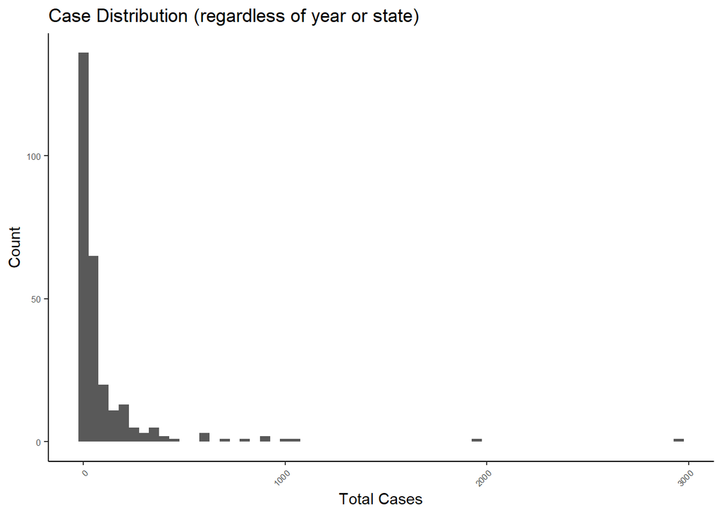

```r
#############################################
#Programming module (West Nile Virus)
#Author: William Norfolk
#Date: 5/18/2020
#############################################

#Load packages
library(tidyverse)

#load data
wnv_data <- read.csv("../raw_data/wnv.csv")

#plot total cases per year for each state
ggplot(wnv_data, aes(Total)) + geom_histogram(binwidth = 50) +
  theme(legend.position = "none", axis.text = element_text(size = 6, family = "bold"),
        axis.text.x = element_text(angle = 45, hjust = 1),
          panel.border = element_blank(),
  panel.grid.major = element_blank(),
  panel.grid.minor = element_blank(),
  axis.line = element_line(colour = "black"),
  panel.background = element_blank()) + xlab("Total Cases") + ylab("Count") + ggtitle("Case Distribution (regardless of year or state)")
```

With each of the following exercises, extend your script so that at the end of the unit you have one script that performs the entire analysis.

**Exercise. The state-level and case burden is evidently highly skewed. Plot a histogram for the logarithm of the number of cases. Do this two different ways.**

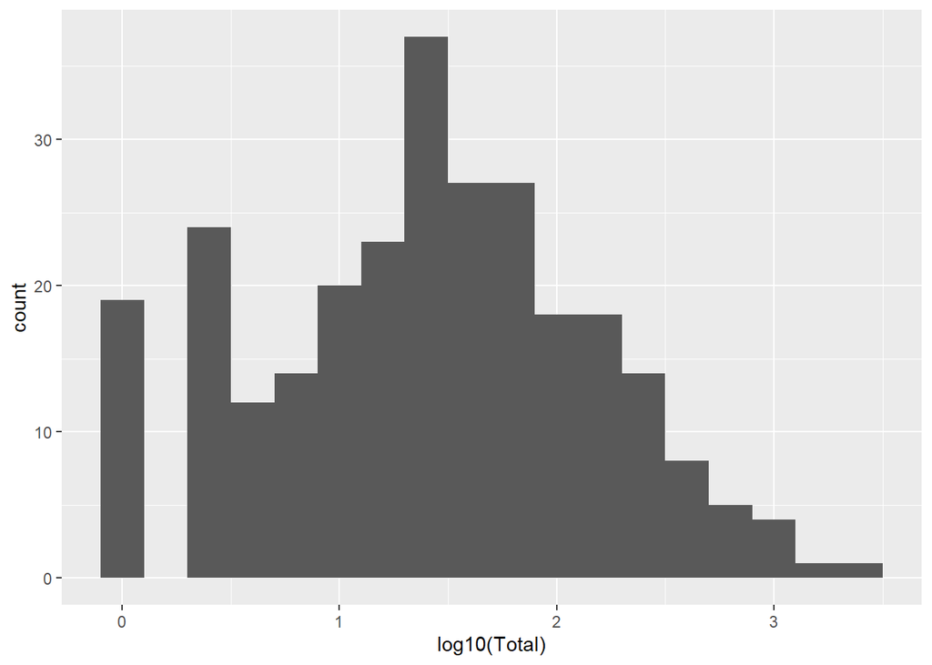

```r
#Option one within the plotting code
ggplot(wnv_data, aes(log10(Total))) + geom_histogram(binwidth = 0.2)
```

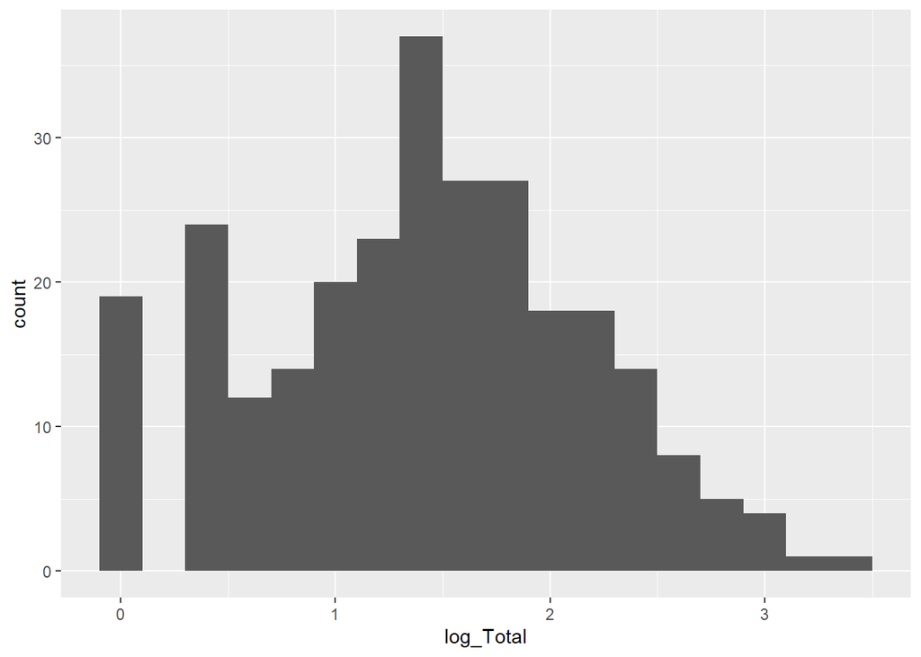

```r
#Option two using mutate to create a log10 variable
wnv_data <- wnv_data %>% dplyr::mutate(log_Total = log10(Total))
ggplot(wnv_data, aes(log_Total)) + geom_histogram(binwidth = 0.2)
```

**Exercise. Use arithmetic operators to calculate the raw case fatality rate (CFR) in each state in each year. Plot a histogram of the calcated CFRs.**

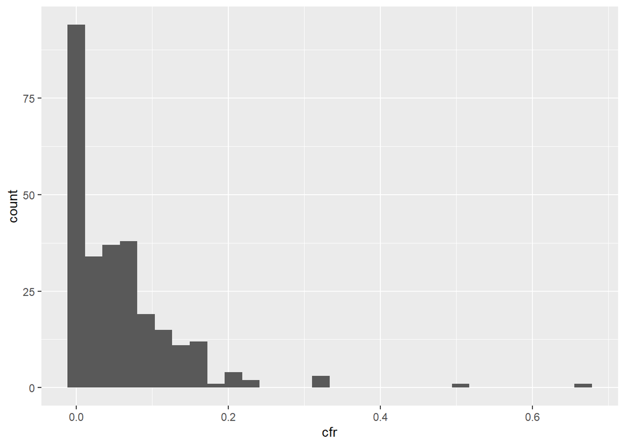

```r
wnv_data <- wnv_data %>% dplyr::mutate(cfr = Fatal / Total)
ggplot(wnv_data, aes(cfr)) + geom_histogram()
```

**Exercise. Use arithmetic operators, logical operators, and the function `sum` to verify that the variable `Total` is simply the sum of the number of febrile cases, neuroinvasive cases, and other cases.**

```r
wnv_data <- wnv_data %>% dplyr::mutate(total_check = EncephMen + Fever + Other)
all(wnv_data$Total == wnv_data$total_check)
```

```
## [1] TRUE
```

**Exercise. Use modular arithmetic to provide an annual case count for each state rounded (down) to the nearest dozen. Use modular arithmetic to extract the rounding errors associated with this calculate, then add the errors to obtain the total error.**

```r
#round the case counts for all entries in the total variable but integer dividing the entry by 12 (to round to dozen) then multiply this by 12 to get the rounded case count.
wnv_data <- wnv_data %>% dplyr::mutate(total_round = (Total %/% 12) * 12)
#Subtract the rounded total from the proper total
wnv_data <- wnv_data %>% dplyr::mutate(error = Total - total_round)
#Sum all error values. Total error = 1241
sum(wnv_data$error)
```

```
## [1] 1241
```

## Functions

Let us call the ratio of meningitis/encephalitis (EncephMen) cases to the total number of cases the *neuroinvasive disease rate*.

**Exercise. Write a function to calculate the mean and standard error (standard deviation divided by the square root of the sample size) of the neuroinvasive disease rate for all the states in a given list and given set of years. Follow the Google R style and remember to place the function near the top of your script. Use your function to calculate the average severe disease rate in California, Colorado, and New York.**

```r
mean_and_stderror <- function(x){
  # Function calculates the mean and standard error
  #
  # Args:
  #   x = a vector of values for which the mean and standard error will be calculated
  #
  # Returns:
  #   the mean and standard error
  #
  # calculates the mean
  m <- mean(x)
  # calculates the standard deviation
  std_deviation <- sd(x)
  # calculates the square root of the sample size (for determining statndard error)
  sqrt_sample_size <- sqrt(length(x))

  # calculates the standard error
  # Computation
  se <- std_deviation/sqrt_sample_size
  return(c(m,se))
}

#Start by computing the neuroinvasive disease rate from raw values
wnv_data <- wnv_data %>% dplyr::mutate(neuro_rate = EncephMen / Total)
```

**Exercise. Use ggplot to show the neurovinvasive disease rate for these states as a bar graph with error bars to show the standard deviation.**

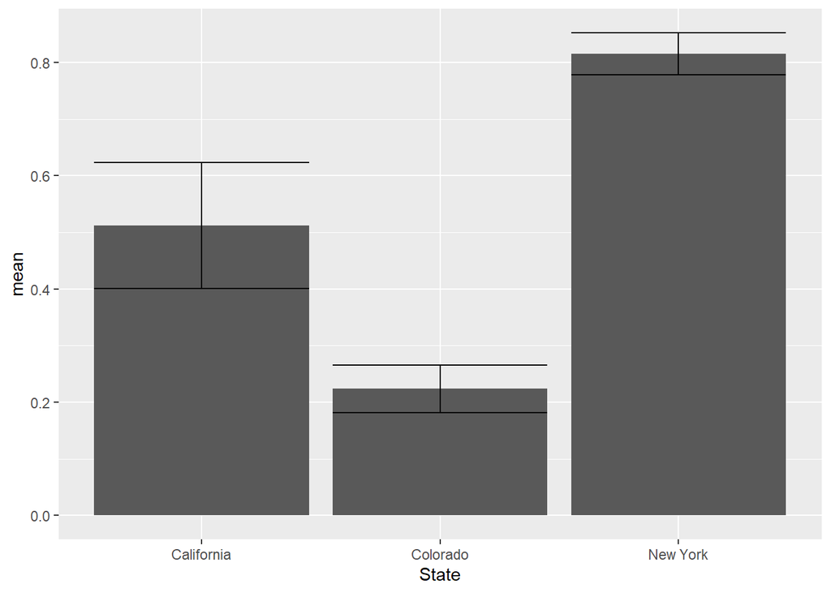

```r
#We will start the the thre subsetted states
#Subset these locations then sort and summarize using the created function. Specify position [1] and [2] to represent mean and standard error respectively.
three_state_fun <- subset(wnv_data, State == "Colorado" | State == "California" | State == "New York") %>%
    group_by(State) %>%
    summarise(mean = mean_and_stderror(neuro_rate)[1],
            stderr = mean_and_stderror(neuro_rate)[2])
#plot the data with errorbars
ggplot(three_state_fun, aes(State, mean)) + geom_bar(stat = "identity") +
  geom_errorbar(aes(State, ymin = mean - stderr, ymax = mean + stderr))
```

```r
#Average neuroinvasive rate in California was 0.5123430 with a standard error of 0.1113079
#Average neuroinvasive rate in Colorado was 0.22358004 with a standard error of 0.04218512
#Average neuroinvasive rate in New York was 0.81486420  with a standard error of 0.03717168
```

**Exercise. Use your function and ggplot to show the neurovinvasive disease rate for all states.**

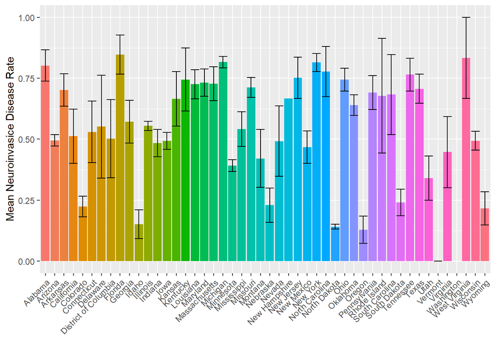

```r
#apply the function to all states
#group by and summarize data by the function while creating two new columns
state_rate_dat <- wnv_data %>%
  group_by(State) %>%
  summarise(mean = mean_and_stderror(neuro_rate)[1],
            stderr = mean_and_stderror(neuro_rate)[2])
#plot summary data
ggplot(state_rate_dat, aes(State, mean, fill = State)) + geom_bar(stat = "identity") +
  geom_errorbar(aes(State, ymin = mean - stderr, ymax = mean + stderr)) + theme(
  axis.text.x = element_text(angle = 45, hjust = 1), legend.position = "none"
) + ylab("Mean Neuroinvasice Disease Rate") + xlab("")
```

## Pipes

**Exercise. Use pipes to produce the same plots without using your function.**

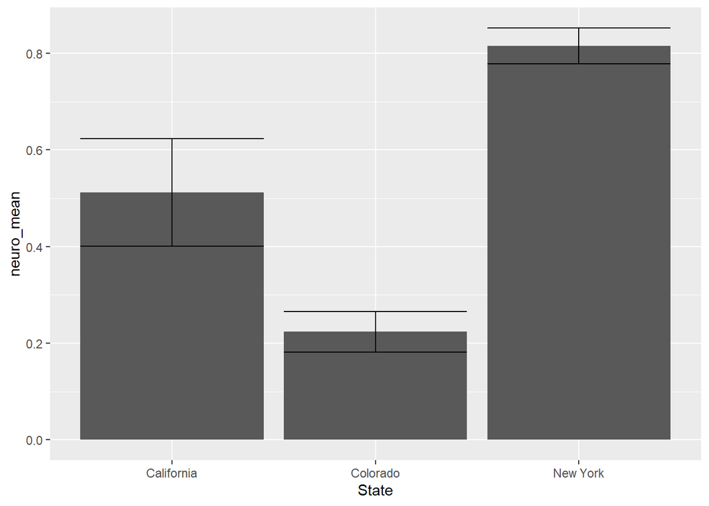

```r
#start with the three states
#use plotrix to simplify standard error calculation
library(plotrix)
ca_co_ny <- subset(wnv_data, State == "Colorado" | State == "California" | State == "New York") %>%
  group_by(State) %>%
  dplyr::summarise(neuro_mean = mean(neuro_rate), standard_error = std.error(neuro_rate))
#then plot as above
ggplot(ca_co_ny, aes(State, neuro_mean)) + geom_bar(stat = "identity") +
  geom_errorbar(aes(State, ymin = neuro_mean - standard_error, ymax = neuro_mean + standard_error))
```

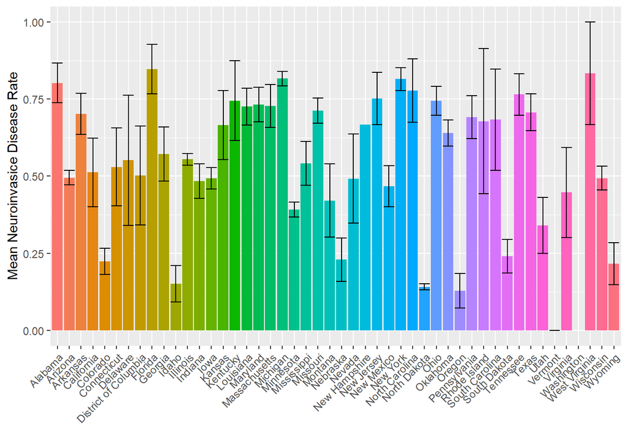

```r
#next move to the full us plot. Will assign a new object (wnv_data_2) to retain our dataframe for continued analysis
wnv_data_2 <- wnv_data %>%
    group_by(State) %>%
  dplyr::summarise(neuro_mean = mean(neuro_rate), standard_error = std.error(neuro_rate))
#Then plot the summaries
ggplot(wnv_data_2, aes(State, neuro_mean, fill = State)) + geom_bar(stat = "identity") +
  geom_errorbar(aes(State, ymin = neuro_mean - standard_error, ymax = neuro_mean + standard_error))+
  theme(axis.text.x = element_text(angle = 45, hjust = 1), legend.position = "none"
) + ylab("Mean Neuroinvasice Disease Rate") + xlab("")
```

## Control of flow

**Conditional execution.** There is evidence that the WNV case fatality rate differs between the Eastern part of the United States and the Western part, probably due to a difference in the mosquito vector species responsible for transmission in different parts of the country. We can use our variable `Longitude` (the longitude of the state centroid) to study this pattern.

**Exercise. Choose a longitude to designate the “center” of the country. Use the function `ifelse` to assign each state to an “Eastern” region or a “Western” region.**

```r
#we will set Kansas as our middle longitude (-98.21)

wnv_data <- wnv_data %>% dplyr::mutate(region = ifelse(Longitude >= -98.21, "Eastern", "Western"))
```

**Exercise. Analyse your data to compare case fatality rates in the Eastern vs. Weestern United States.** *It appears that the Eastern states have a higher case fatality rate when compared to western states.*

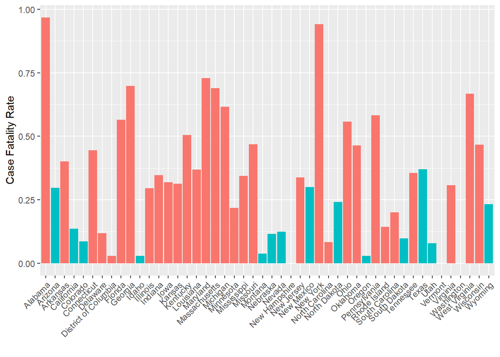

```r
#make total plot
ggplot(wnv_data, aes(x = State, y = cfr, fill = region)) + geom_bar(stat = "identity") +
   theme(axis.text.x = element_text(angle = 45, hjust = 1), legend.position = "none") + xlab("") + ylab("Case Fatality Rate")
```

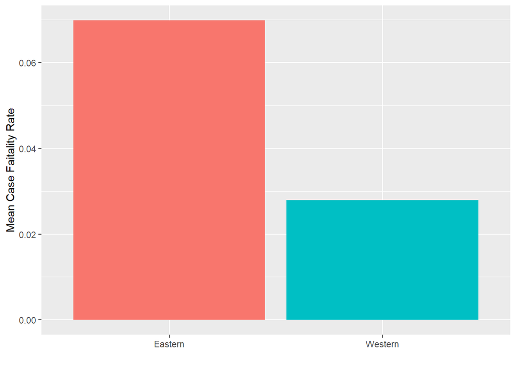

```r
#summarize data to view averages by region
region_data <- wnv_data %>%
  group_by(region) %>%
  dplyr::summarise(cfr_mean = mean(cfr), standard_error = std.error(cfr))

ggplot(region_data, aes(region, cfr_mean, fill = region)) + geom_bar(stat = "identity") +
  theme(legend.position = "none") + xlab("") + ylab("Mean Case Faitality Rate")
```

**Exercise. Is there evidence for a *latitudinal gradient* in case fatality rate?** *Based on the plots below, there is evidence of a latitudinal gradient where Southern States appear to have a higher case fatality rate. Though it should be noted that there difference between the two regions is minor on average and variable by state.*

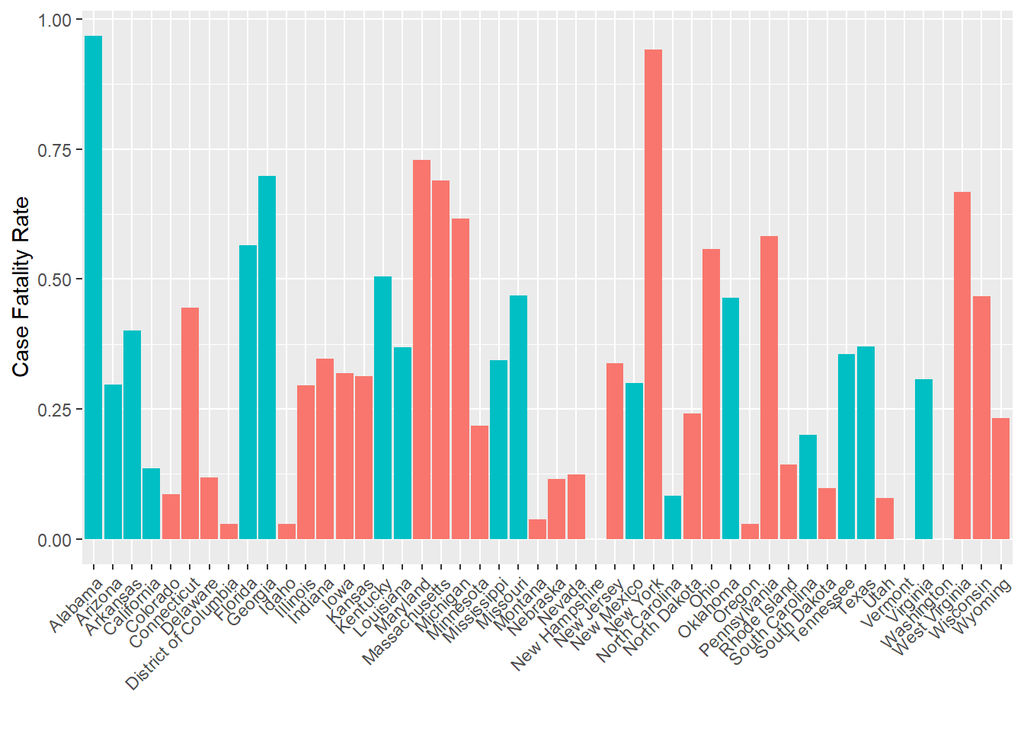

```r
#Since kansas is fairly mid country we will also use this state for latitude
wnv_data <- wnv_data %>% dplyr::mutate(region_lat = ifelse(Latitude >= 38.56, "Northern", "Southern"))

#will replicate the code as above for latitude
#make total plot
ggplot(wnv_data, aes(x = State, y = cfr, fill = region_lat)) + geom_bar(stat = "identity") +
   theme(axis.text.x = element_text(angle = 45, hjust = 1), legend.position = "none") + xlab("") + ylab("Case Fatality Rate")
```

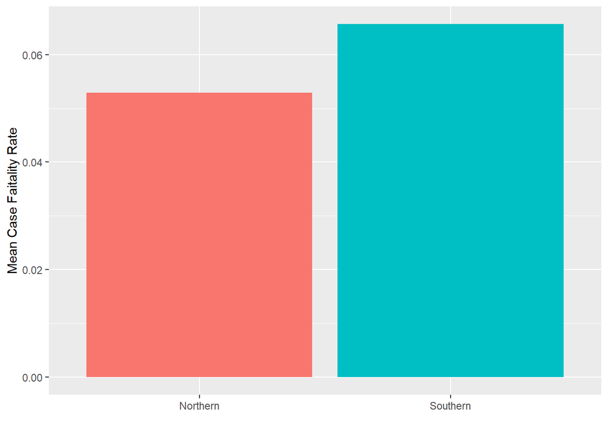

```r
#summarize data to view averages by region
region_lat_data <- wnv_data %>%
  group_by(region_lat) %>%
  dplyr::summarise(cfr_mean = mean(cfr), standard_error = std.error(cfr))

ggplot(region_lat_data, aes(region_lat, cfr_mean, fill = region_lat)) + geom_bar(stat = "identity") +
  theme(legend.position = "none") + xlab("") + ylab("Mean Case Faitality Rate")
```

**Loops.** One useful task for looping is to select parts of a data set for analysis following an algorithm. For instance, analysis can be performed over a series of time points or regions using a script with the following architecture.

```r
times <- seq(1:10)
some.algorithm <- function(t){
  y <- t * 10  # a silly example
}
output <- c() # Question: What is this line doing? Answer: This line takes the output values designated by the function and forms them into a list called "output" which is then used for plotting. In this example the function multiples all values in the sequence by 10 creating a positive linear scatterplot.
for(t in times){
  output <- c(output, some.algorithm(t))
}
output
plot(times, output, type='p')
```

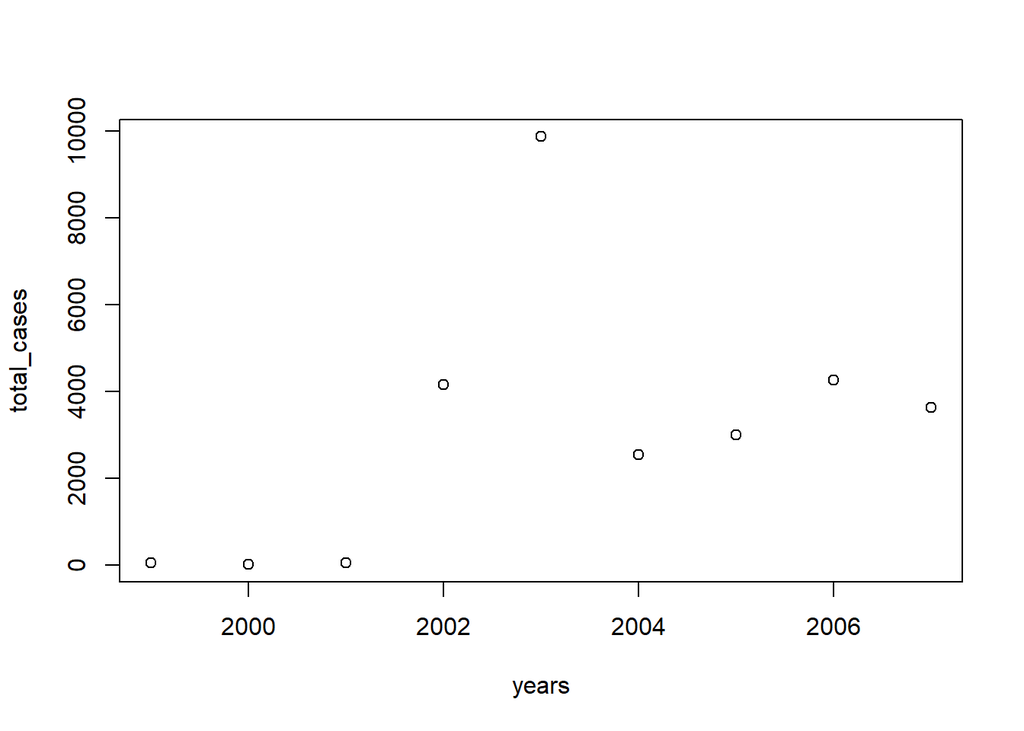

```r
#set years sequence
years <- unique(wnv_data$Year)

#loop over years to find total cases
total_cases <- c()
for(year in years){
  look.at <- wnv_data$Year == year #Look.at is a boolean vector that directs the outcome of each iteration
 total_cases <- append(total_cases, sum(wnv_data$Total[look.at], na.rm = TRUE))
}

#add yearly cases plot
plot(years, total_cases, type='p')
```

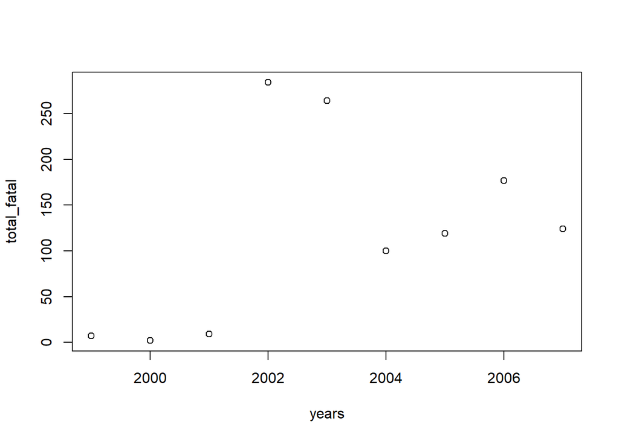

```r
#loop over years to find total fatalities
total_fatal <- c()
for(year in years){
  look.at <- wnv_data$Year == year #Look.at is a boolean vector that directs the outcome of each iteration
 total_fatal <- append(total_fatal, sum(wnv_data$Fatal[look.at], na.rm = TRUE))
}

#add yearly fatalities plot
plot(years, total_fatal, type='p')
```

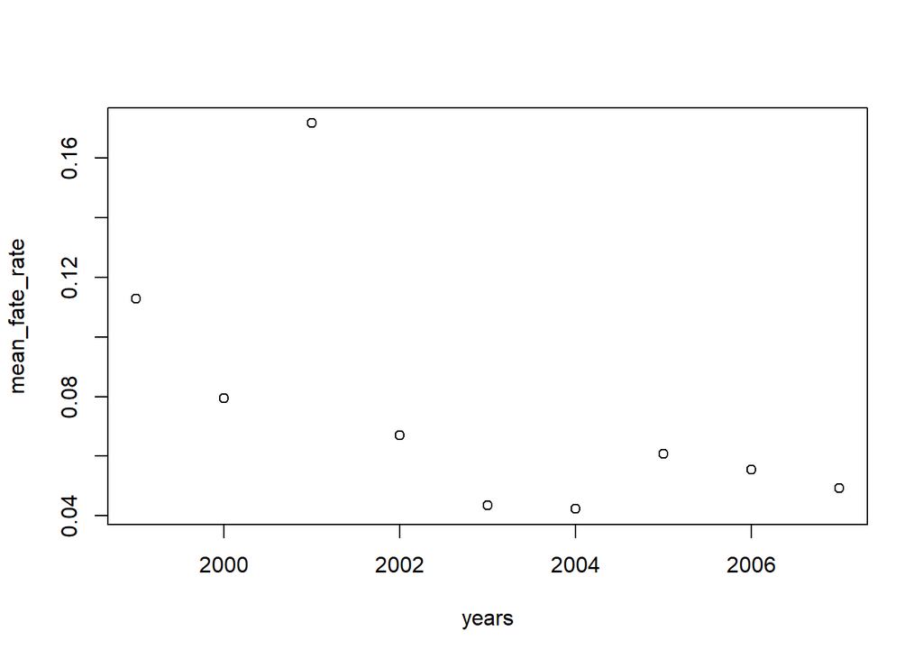

```r
#loop over years to find mean fatality rate
mean_fate_rate <- c()
for(year in years){
  look.at <- wnv_data$Year == year #Look.at is a boolean vector that directs the outcome of each iteration
 mean_fate_rate <- append(mean_fate_rate, mean(wnv_data$cfr[look.at], na.rm = TRUE))
}

#add yearly case fatality rate plot
plot(years, mean_fate_rate, type='p')
```

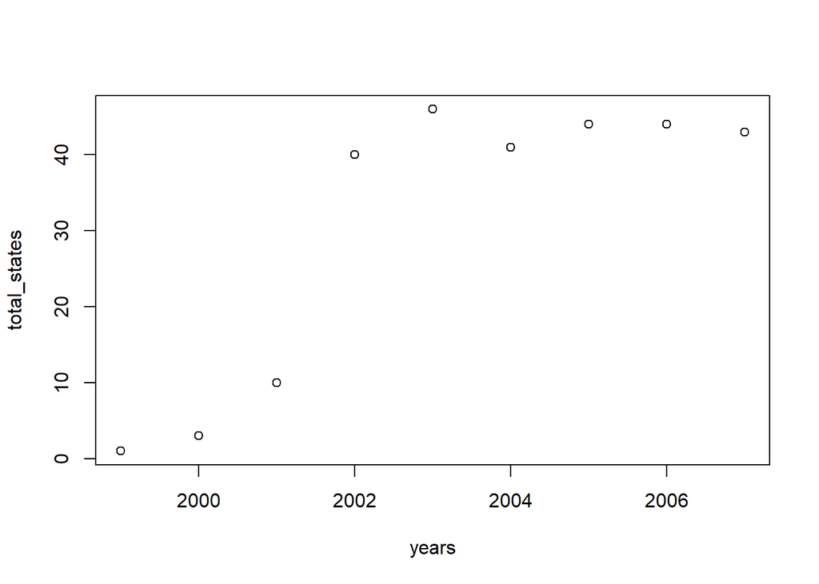

```r
#loop over years to find total reporting states
total_states <- c()
for(year in years){
  look.at <- wnv_data$Year == year #Look.at is a boolean vector that directs the outcome of each iteration
 total_states <- append(total_states, length(unique(wnv_data$State[look.at], na.rm = TRUE)))
}

#add yearly cases plot
plot(years, total_states, type='p')
```

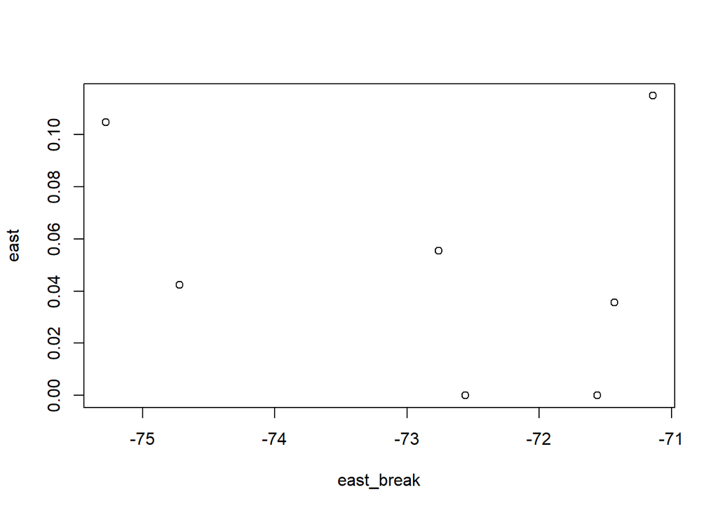

```r
#Not the tidy-est code I have ever made

#set breakpints into a vector
breakpoints <- wnv_data$Longitude
#create empty objects for data storage
east <- NULL
west <- NULL
east_break <- NULL
west_break <- NULL

#loop through breakpoints
for(i in breakpoints){
 look.at <- wnv_data$Longitude == i[i] #set boolean
  if(wnv_data$Longitude <= i){
    east <- append(east, mean(wnv_data$cfr[look.at], na.rm = TRUE))
    east_break <- append(east_break, unique(wnv_data$Longitude[look.at])) #create for comparable vector length
  }
  else{
    west <- append(west, mean(wnv_data$cfr[look.at], na.rm = TRUE))
    west_break <- append(west_break, unique(wnv_data$Longitude[look.at]))
  }
}
#plot results
plot(east_break, east, type = 'p')
```

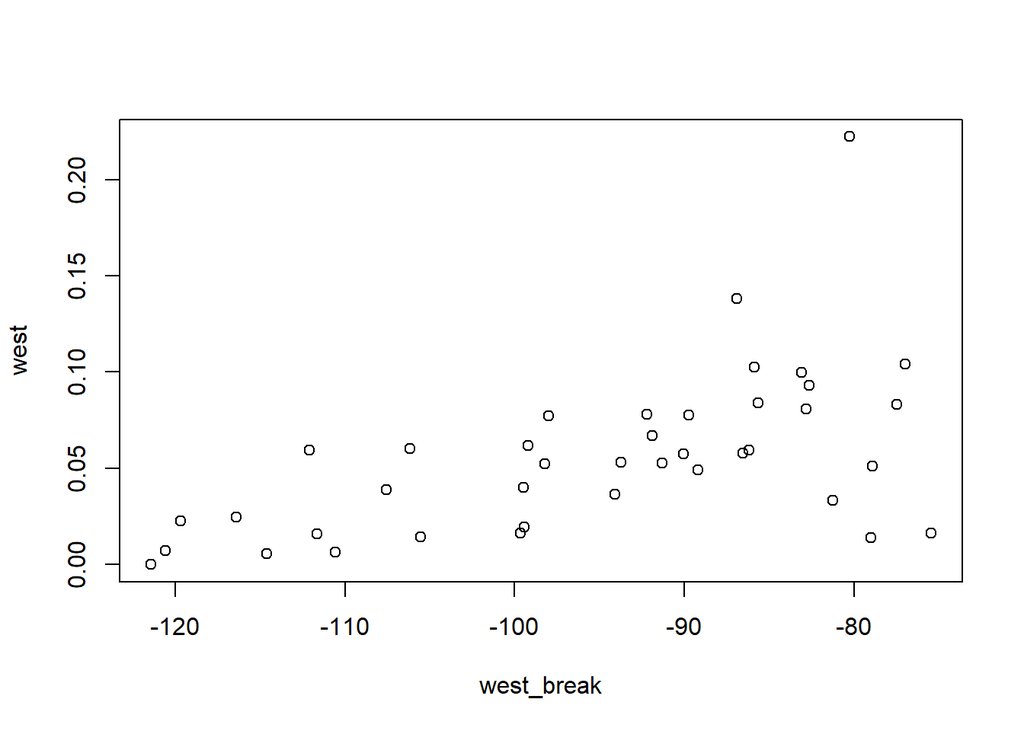

```r
plot(west_break, west, type = 'p')
```

## Using help

Using the help functions, i.e., reading the argument list, methods, usage, etc. and being example to apply or extend examples to a new case is an important programming skill (albeit one that doesn’t involve any programming!). In this section we practice reading and using R help.

**Exercise. We may interpret raw case fatality rate (i.e. ratio of the number of deaths, $x$, to number of infections, $n$) as a realization from a binomial process with $n$ trials and $x$ “successes” generated by an unknown rate parameter $p$. This $p$ may be the quantity truly of interest (for instance, if we wish to ask if the case fatality rate in California is significantly different from the case fatality rate in Colorado. In R, the *estimated rate* and its *confidence interval* can be obtained using the function `prop.test` for testing equal proportions. Use the help to determine the proper usage of `prop.test` and calculate confidence intervals for the case fatality rates in all states for which there have been reported cases of WNV.** *The prop.test function runs a porportion test which tells us how probable it is that two porportions are the same. Lower prop.test values indicate differences where a higher number would indicate similaraity.*

```r
#pull help tab for prop.test
?prop.test

#test prop.test for all states with reported values
#aggregate to mean cfr for each state
wnv_prop_test <- wnv_data %>%
    group_by(State) %>%
    dplyr::summarise(cfr_mean = mean(cfr)) %>%
    dplyr::mutate(recover_mean = 1 - cfr_mean)
state_names <- wnv_prop_test$State
wnv_prop_test <- wnv_prop_test %>% select(-State)
wnv_prop_test_2 <- as.matrix(wnv_prop_test)
rownames(wnv_prop_test_2) <- state_names #retain state names
#run prop.test by states
prop_result <- prop.test(wnv_prop_test_2)
prop_result
```

```
##
##  48-sample test for equality of proportions without continuity
##  correction
##
## data:  wnv_prop_test_2
## X-squared = 1.6338, df = 47, p-value = 1
## alternative hypothesis: two.sided
## sample estimates:
##      prop 1      prop 2      prop 3      prop 4      prop 5      prop 6
## 0.138186510 0.059456117 0.066759270 0.022557644 0.014405656 0.055555556
##      prop 7      prop 8      prop 9     prop 10     prop 11     prop 12
## 0.029411765 0.005882353 0.080713032 0.099768089 0.005732019 0.049214378
##     prop 13     prop 14     prop 15     prop 16     prop 17     prop 18
## 0.057869508 0.053143990 0.052300168 0.084126984 0.052721663 0.104039416
##     prop 19     prop 20     prop 21     prop 22     prop 23     prop 24
## 0.114876385 0.102568004 0.036412175 0.057342401 0.077967075 0.006303333
##     prop 25     prop 26     prop 27     prop 28     prop 29     prop 30
## 0.019318199 0.024731183 0.000000000 0.042279412 0.060039872 0.104651531
##     prop 31     prop 32     prop 33     prop 34     prop 35     prop 36
## 0.013888889 0.040196690 0.092931754 0.077271025 0.007246377 0.083173437
##     prop 37     prop 38     prop 39     prop 40     prop 41     prop 42
## 0.035714286 0.033333333 0.016201798 0.059230122 0.061590678 0.015889553
##     prop 43     prop 44     prop 45     prop 46     prop 47     prop 48
## 0.000000000 0.051237843 0.000000000 0.222222222 0.077758026 0.038747604
```

**Exercise. The “See Also” section of the help for `prop.test` states that a different function might be useful for an exact test of our hypotheses. Use the help to identify what this function is, learn how to use it, and compare the differences.** *The function is called a binom.test which compares the number of successess in a given number of trials with a hypothesized probability of success. For this function x denotes the number of successes, n denotes the number of trials and p is the probability of success.*

```r
#we can recycle or dataframe from above here.
wnv_prop_test_2 <- as.tibble(wnv_prop_test_2)
binom_vec <- round(wnv_prop_test_2$cfr_mean * 100) #Will use 100 trials for this example and assume that fatality is "success" interms of the binom.test to compare with the prop.test
#I was unable to determine how to apply the binom.test function to a full list of successful outcomes due to a persistant vector length error so I selected a few random states below to compare

#Alabama
binom.test(14, 100, p =0.5) #Compares to prop 1 test above
```

```
##
##  Exact binomial test
##
## data:  14 and 100
## number of successes = 14, number of trials = 100, p-value = 8.284e-14
## alternative hypothesis: true probability of success is not equal to 0.5
## 95 percent confidence interval:
##  0.0787054 0.2237280
## sample estimates:
## probability of success
##                   0.14
```

```r
#Connecticut
binom.test(6, 100, p =0.5) #Compares to prop 6 test above
```

```
##
##  Exact binomial test
##
## data:  6 and 100
## number of successes = 6, number of trials = 100, p-value < 2.2e-16
## alternative hypothesis: true probability of success is not equal to 0.5
## 95 percent confidence interval:
##  0.02233489 0.12602993
## sample estimates:
## probability of success
##                   0.06
```

```r
#West Virginia
binom.test(22, 100, p =0.5) #Compares to prop 46 test above
```

```
##
##  Exact binomial test
##
## data:  22 and 100
## number of successes = 22, number of trials = 100, p-value = 1.591e-08
## alternative hypothesis: true probability of success is not equal to 0.5
## 95 percent confidence interval:
##  0.1433036 0.3139197
## sample estimates:
## probability of success
##                   0.22
```

```r
#The results of both tests appear to be relatively similar with the major differences likely due to the rounding of successes in the binom.test data prep.
```

[^1]: Contributions to lectures and practicals by Andrew W. Park, John M. Drake and Ana I. Bento